# Animated species distribution maps with {gifski}

One useful way to see changes in a species’ habitat range over time is by using animation to view multiple distributions in succession. Here we will model the distribution of *Nudibranchia* across Australia each month to create an animated GIF of its distribution over a year.

Eukaryota

Animalia

Mollusca

Maps

R

Intern-post

Authors

Stephanie Woolley

Olivia Torresan

Dax Kellie

Published

March 14, 2023

Modified

October 20, 2026

#### Author

Stephanie Woolley  
[Olivia Torresan](https://labs.ala.org.au/about/Torresan_Olivia/index.html)  
[Dax Kellie](https://labs.ala.org.au/about/Kellie_Dax/index.html)

#### Date

14 March 2023

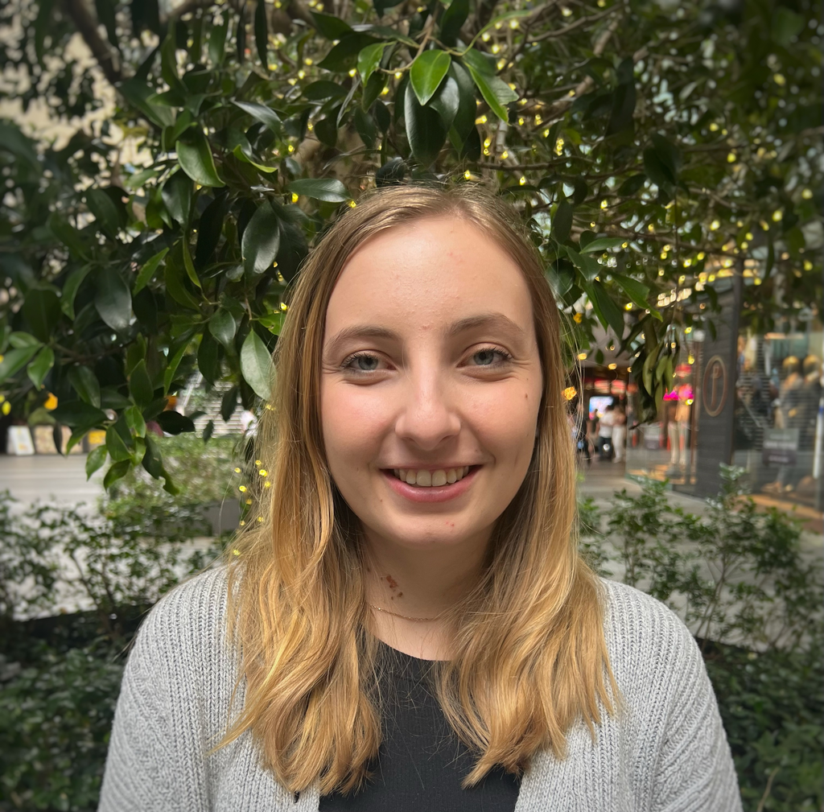

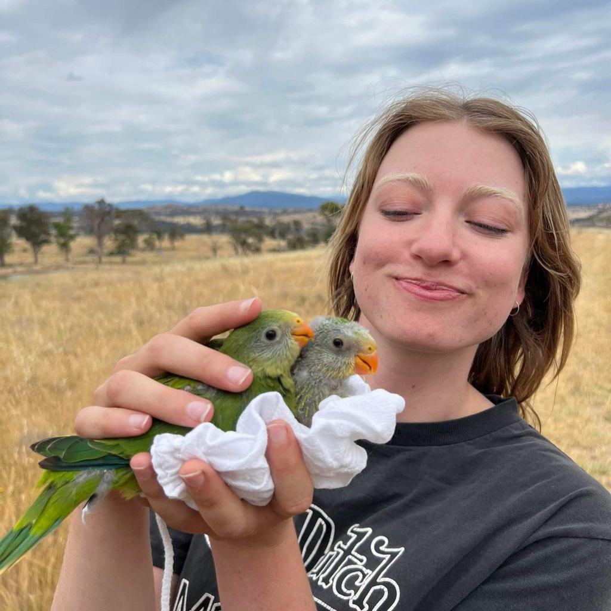

**TipIntern Post**

Each species has a habitat range where it normally lives and can expect to be found over its lifetime. However, individuals of a species rarely stay in the same spot for long periods of time. Just like us, they react to changes in their environment, interactions with other species, and interactions with other individuals.

As a result, it can be useful to see how a distribution of a species changes in space *and* over time. In marine environments, for example, seemingly small changes in [temperature](https://theconversation.com/the-mediterranean-has-experienced-record-sea-temperatures-this-summer-this-could-devastate-marine-life-188995), [chemicals](https://theconversation.com/marine-life-in-a-south-african-bay-is-full-of-chemical-pollutants-182791) and [light](https://theconversation.com/the-moon-and-stars-are-a-compass-for-nocturnal-animals-but-light-pollution-is-leading-them-astray-142301) can result in large changes to a species’ distribution.

Here we will map the distribution of *Nudibranchia* around Australia each month as an animated map to see how nudibranch distributions change over the year.

This post is inspired by [Liam Bailey’s](https://twitter.com/ldbailey255) cool (and hilarious) [Bigfoot distribution map](https://twitter.com/ldbailey255/status/1575541015951593472). You can find his code [here](https://github.com/LiamDBailey/TidyTuesday/blob/93cbe1143757c97ddaf36c564ac03a2b8088cb56/R/2022/Week37_2022.qmd).

# Download data

## Occurrence data

Let’s first download observations of *Nudibranchia* across Australia.

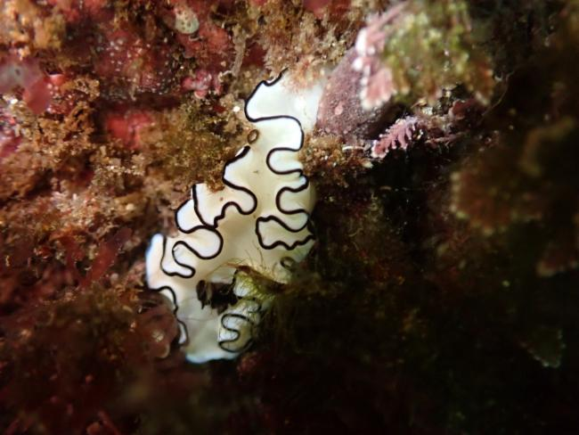

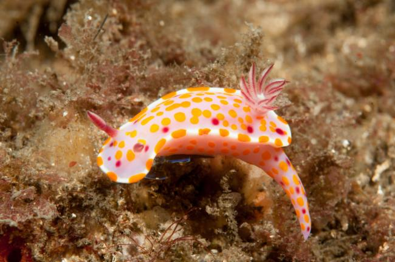

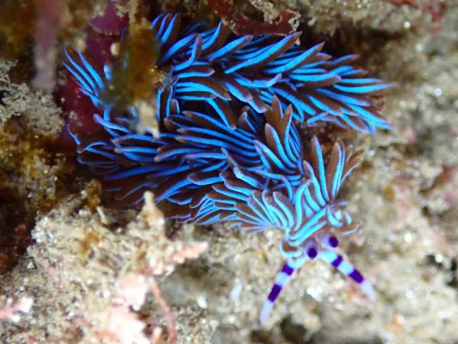

Left: [*Doriprismatica atromarginata* (diana88jingfung CC-BY-NC 4.0 (Int))](https://biocache.ala.org.au/occurrences/4a9786d3-f68f-4bbe-9eae-38b83849ae89) Middle: [*Ceratosoma amoenum* (Erik Schlogl CC-BY-NC 4.0 (Int))](https://biocache.ala.org.au/occurrences/fde8a631-e295-4334-87fc-659e2f650e08) Right: [*Pteraeolidia ianthina* (Jallitt CC-BY-NC 4.0 (Int))](https://biocache.ala.org.au/occurrences/c5bf023e-a19d-4e75-8265-009e3493c9ef)

We’ll load the necessary packages.

```r
library(galah)
library(tidyverse)
library(glue)
library(lubridate)
library(stars)         # Raster management
library(ozmaps)        # Australian map
library(SSDM)          # Linear modelling
library(sdmpredictors) # Environmental variables
library(grDevices)     # Colours and fonts
library(maps)          # Cities for map
library(tmaptools)     # Create plot ratio
library(gifski)        # Create GIF
library(knitr)         # View GIF
library(feathers)      # remotes::install_github(repo = "shandiya/feathers", ref = "main")
```

Now we will use the {`galah`} package to download observations of *Nudibranchia*.

You will need to provide a [registered email with the ALA](https://auth.ala.org.au/userdetails/registration/createAccount) to `galah_config()` before retrieving records.

```r
# Add registered email (register at ala.org.au)
galah_config(email = "your-email@email.com")
```

```r
# Download observations
nudibranch_occurrences <-
  galah_call() |>
  galah_identify("Nudibranchia") |>
  galah_filter(country == "Australia") |>
  galah_apply_profile(ALA) |> # ALA's set of data cleaning filters
  atlas_occurrences()
```

## Environmental variables

Now we will download our environmental variables for our model.

For our *Nudibranchia* model, we will use 4 common marine environmental variables:

- Sea surface temperature
- Sea surface salinity
- Distance to shore
- Bathymetry

To get them, we’ll use `load_layers()` from the [{sdmpredictors} package](https://github.com/lifewatch/sdmpredictors) to download our variables as raster layers (geographic layers that have a value per pixel of our variable). We’ll use the `rasterstack` argument to combine our layers into one object.

**Note**

The {sdmpredictors} package has lots of data sets and layers available. [Check out their website to learn more](http://lifewatch.github.io/sdmpredictors/articles/quickstart.html).

```r
# Download variables
env <- load_layers(layercodes = c("MS_biogeo08_sss_mean_5m",
                                  "MS_biogeo13_sst_mean_5m",
                                  "MS_biogeo05_dist_shore_5m",
                                  "MS_bathy_5m"),
                   equalarea = FALSE,
                   rasterstack = TRUE)
```

To prepare variable data for our model, we need to crop the geographical boundaries of our data to include *only* the coast (and surrounding ocean) of Australia. With the help of the {raster} package, we’ll use `extent()` to set the outer boundaries and `crop()` to remove the land.

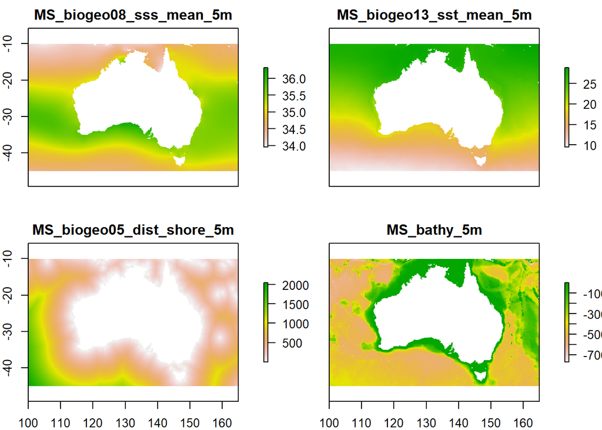

```r
# Create extent
aus_ext <- raster::extent(100, 165, -45, -10)

# Limit environmental variables
aus_env <- raster::crop(env, aus_ext)

# Check variables
plot(aus_env)
```

# Prepare data

To construct our animated GIF, we can make each “frame” of our animation a species distribution map of each month - that means 12 maps, January to December.

In order to do this, we’ll create a set of custom functions that:

1. Filter all observations to only observations of a specific month,
2. Run a species distribution model on those observations
3. Plot the results onto a map
4. Save the maps

By making custom functions for these tasks, we’ll be able to run each function in a loop, letting us do each thing 12 times for each of our 12 months.

At the end, we’ll stitch our 12 maps together and, *Voila*! We’ll officially be animators (Pixar here we come!).

First we’ll filter out `NA` values and duplicates (which might cause our model to error) and extract the month of observation into its own column.

```r
# Clean, filter and convert time series to months
occurrences_clean <-
  nudibranch_occurrences |>
  filter(!is.na(decimalLatitude) & !is.na(decimalLongitude)) |>
  filter(!duplicated(decimalLatitude) & !duplicated(decimalLongitude)) |>
  mutate(month = month(eventDate)) |>
  select(month, decimalLatitude, decimalLongitude)

head(occurrences_clean)
```

```
# A tibble: 6 × 3
  month decimalLatitude decimalLongitude
  <dbl>           <dbl>            <dbl>
1     9           -28.1             153.
2    11           -35.0             151.
3     9           -32.7             152.
4     7           -21.8             114.
5    NA           -21.8             114.
6    10           -38.4             145.
```

From here, we’ll make our own function `make_months_df()` that filters our overall observations to only those of our chosen month.

```r
# Build function (for each month select the lat and long)
make_months_df <- function(chosen_month) {
  monthly_data <- occurrences_clean %>%
    filter(month == {{chosen_month}}) %>%
    select(decimalLatitude, decimalLongitude)
}
```

With the help of `purrr::map()` we can run a loop over our `make_months_df()` function to return our 12 `data.frame`s in one `list`.

```r
n_months <- c(1:12)
month_list <- purrr::map(n_months, make_months_df)

month_list[[1]] # See output of month 1
```

```
# A tibble: 3,026 × 2
   decimalLatitude decimalLongitude
             <dbl>            <dbl>
 1           -38.3             145.
 2           -14.7             145.
 3           -38.3             145.
 4           -32.0             116.
 5           -38.4             145.
 6           -33.1             152.
 7           -26.8             153.
 8           -38.4             145.
 9           -19.1             147.
10           -26.7             153.
# ℹ 3,016 more rows
```

# Species Distribution Model

Now that `month_list` contains our 12 `data.frame`s, we can run some models with them to calculate a distribution surface.

To build our overall Species Distribution Model (SDM) we’ve chosen to use [the method used by Liam Bailey in his Bigfoot map](https://github.com/LiamDBailey/TidyTuesday/blob/93cbe1143757c97ddaf36c564ac03a2b8088cb56/R/2022/Week37_2022.qmd). It’s a fairly flexible model that suits our purposes to quickly see where nudibranchs are observed around Australia.

We’ll build another custom function to run these models called `run_sdm_model()` for each chosen month.

**Note**

This SDM method merges the results from several models into one final value using [Fisher’s combined probability](https://en.wikipedia.org/wiki/Fisher%27s_method). It’s by no means the most robust SDM. If you are trying to make a more informative species distribution model, it might be worth considering [other methods](https://www.frontiersin.org/articles/10.3389/fmars.2017.00421/full)!

```r
# Species distribution model function
run_sdm_model <- function(chosen_month) {
  SDM_GLM <- modelling("GLM",
    Occurrences = (chosen_month),
    Env = aus_env,
    Xcol = "decimalLongitude",
    Ycol = "decimalLatitude",
    verbose = FALSE
  )
  SDM_MARS <- modelling("MARS",
    Occurrences = (chosen_month),
    Env = aus_env,
    Xcol = "decimalLongitude",
    Ycol = "decimalLatitude",
    verbose = FALSE
  )
  SDM_CTA <- modelling("CTA",
    Occurrences = (chosen_month),
    Env = aus_env,
    Xcol = "decimalLongitude",
    Ycol = "decimalLatitude",
    verbose = FALSE
  )

  # Calculate single value using Fisher's combined probability
  combined <- -2 * (log(SDM_MARS@projection) + log(SDM_GLM@projection) + log(SDM_CTA@projection))
  Chi_sq <- function(x) {1 - pchisq(q = x, df = 6)}
  combined_pval <- raster::calc(combined, fun = Chi_sq)

  # Convert to spatial object
  species_distribution <- stars::st_as_stars(combined_pval)
  return(species_distribution)
}
```

Now we can use `purrr::map()` to run another loop to return results of our 12 SDMs.

```r
# Run & save models
model_list <- purrr::map(month_list, run_sdm_model)
```

# Map

We now have the results of our 12 SDMs in `model_list`. We can use these results to make 12 maps.

To help orient ourselves, let’s download point data of the main cities in Australia from the {maps} package.

```r
city_names <- c("Sydney", "Melbourne", "Brisbane", "Cairns",
                "Canberra", "Adelaide", "Melbourne", "Perth", "Darwin")

cities <- world.cities |>
  filter(country.etc == "Australia") |>
  filter(name %in% city_names)
```

Let’s also make a nice colour palette:

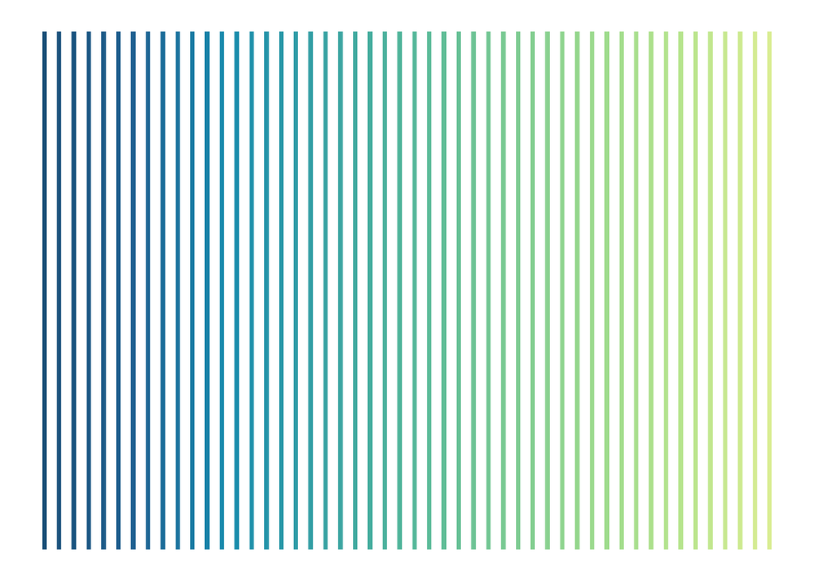

```r
blue_yellow <- c( "#184E77", "#1E6091",  "#168AAD",  "#34A0A4",  "#52B69A",
                  "#76C893", "#99D98C", "#B5E48C",  "#D9ED92")

colour_palette <- colorRampPalette(blue_yellow)(50)
feathers::print_pal(colour_palette)
```

Now we are ready to make maps of our results!

We’ll once again make a custom function `make_the_map()` to construct each map. This function not only constructs our maps, but adds each month’s 3-letter abbreviation `month_label` to the top of each map for our eventual animation.

For this, let’s make some month labels:

```r
# Get label for each month
month_label <- month(1:12, label = TRUE)
month_label
```

```
 [1] Jan Feb Mar Apr May Jun Jul Aug Sep Oct Nov Dec
12 Levels: Jan < Feb < Mar < Apr < May < Jun < Jul < Aug < Sep < ... < Dec
```

And now we’ll create our `make_the_map()` function:

```r
# Map making function (for monthly SDM build this map)
make_the_map <- function(model_data, month_label) {

  month <- {{month_label}}

  ggplot() +
    geom_stars(data = model_data) +
    geom_sf(data = ozmaps::ozmap_states,
            colour = "#A9A793",
            fill = "#C8C6AF") +
    coord_sf(crs = "WGS84",
             xlim = c(112, 154),
             ylim = c(-43, -11)) +
    scale_fill_gradientn(colours = c(colour_palette),
                         limits = c(0, 1),
                         guide = guide_colourbar(
                           title = "Occurrence\nprobability",
                           title.theme = element_text(
                             family = "Times New Roman",
                             colour = "#3D4040",
                             size = 10,
                             face = "bold"),
                           label.theme = element_text(
                             colour = "#3D4040",
                             size = 8),
                           ticks = FALSE,
                           frame.colour = "#3D4040",
                           title.position = "top",
                           title.vjust = 2,
                           label.position = "left"),
                         breaks = c(0, 0.5, 1),
                         labels = c("0%", "50%", "100%")) +
    # Title map with month
    labs(title = glue("{month_label}")) +
    theme_void() +
    theme(
      legend.position = c(1.2, 0.2), # reposition legend
      plot.title = element_text(size = 26),
      legend.direction = "vertical",
      plot.background = element_rect(fill = "#FFFFFF", colour = NA),
      plot.margin = unit(c(0.01, 2.5, 0.1, 0.1), "cm")) +
    # Add city points
    geom_point(data = cities,
               aes(x = long, y = lat),
               size = 2,
               colour = "#782717",
               fill = "white",
               shape = 21) +
    # Add city labels
    ggrepel::geom_text_repel(data = cities,
              aes(x = long, y = lat, label = name),
              colour = "white",
              nudge_x = .12, nudge_y = .1,
              hjust = "inward",
              vjust = "inward",
              fontface = "bold",
              size = 6.8,
              family = "Times New Roman")
}
```

We can use `map2()` to make all of our maps:

```r
# generate maps
all_maps <- model_list %>%
  map2(
    .x = .,
    .y = month_label,
    .f = make_the_map
  )
```

Now to save our maps. We’ll assign our plots a letter so they are ordered alphabetically and saved in order in a new folder called `maps`.

To figure out the best aspect ratio to save our maps, we’ll use the `get_asp_ratio()` function from the {tmaptools} package, and use it calculate the width of our plots. Finally, we can use `purrr::walk2()` to loop through `ggsave()` and save our maps.

```r
# set names of plots to save
letter_id <- as.list(letters[1:12]) # saves in correct order for gif
plotnames <- purrr::map(letter_id, ~glue("maps/map_{.x}.png"))

# save plots
plot_ratio <- get_asp_ratio(model_list[[1]]) # aspect ratio

walk2(plotnames, all_maps, ~ggsave(filename = .x,
                                   plot = .y,
                                   height = 9,
                                   width = plot_ratio*10))
```

We should now have 12 species distribution maps saved, and we can see them by returning all the files in our `maps` folder.

```r
map_files <- list.files(path = "maps/")
map_files
```

```
 [1] "map_a.png" "map_b.png" "map_c.png" "map_d.png" "map_e.png" "map_f.png"
 [7] "map_g.png" "map_h.png" "map_i.png" "map_j.png" "map_k.png" "map_l.png"
```

# Make GIF

For context before we see our animation, let’s first look at the distribution of all nudibranchs across Australia (this uses all the same code as above, but without all the looping)

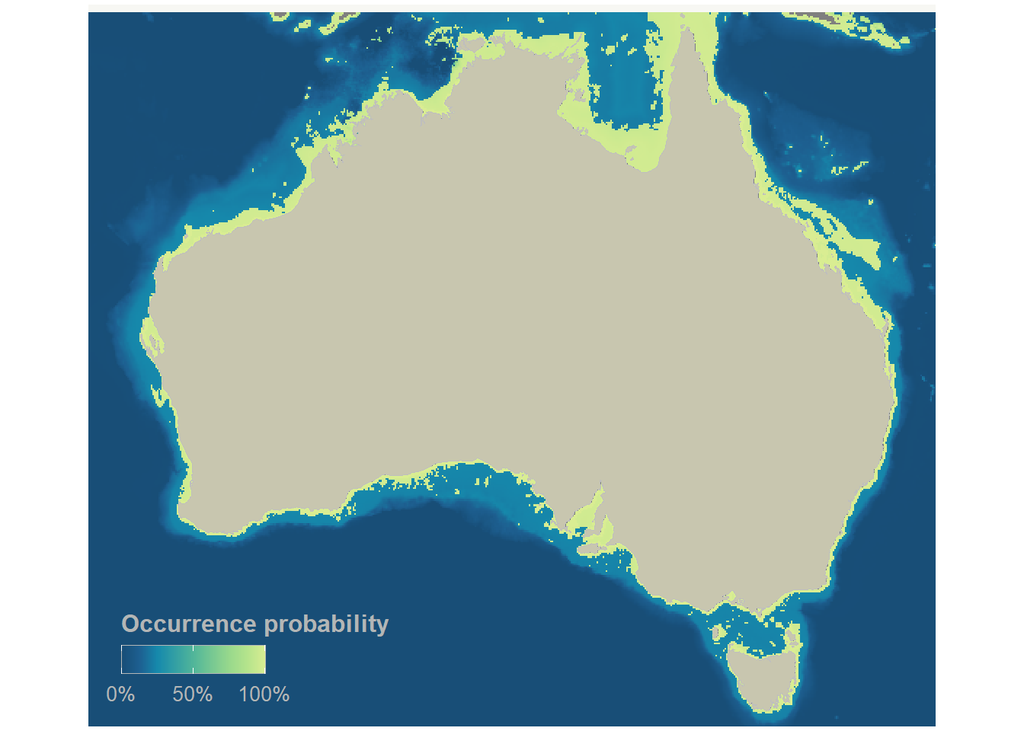

```r
## Run the 3 models on our data
SDM_GLM <- modelling("GLM",
                     Occurrences = occurrences_clean,
                     Env = aus_env,
                     Xcol = 'decimalLongitude',
                     Ycol = 'decimalLatitude',
                     verbose = FALSE)
SDM_MARS <- modelling("MARS",
                      Occurrences = occurrences_clean,
                      Env = aus_env,
                      Xcol = 'decimalLongitude',
                      Ycol = 'decimalLatitude',
                      verbose = FALSE)
SDM_CTA <- modelling("CTA",
                     Occurrences = occurrences_clean,
                     Env = aus_env,
                     Xcol = 'decimalLongitude',
                     Ycol = 'decimalLatitude',
                     verbose = FALSE)

combined <- -2 * (log(SDM_MARS@projection) + log(SDM_GLM@projection) + log(SDM_CTA@projection))
Chi_sq <- function(x){1 - pchisq(q = x, df = 6)}
combined_pval <- raster::calc(combined, fun = Chi_sq)
species_distribution <- stars::st_as_stars(combined_pval)


## MAP

ggplot() +
  geom_stars(data = species_distribution) + # Plot SDM results
  geom_sf(data = ozmaps::ozmap_country, # Add Australian map
          colour = "grey",
          fill = "#C8C6AF") +
  coord_sf(crs = "WGS84", # Set geographical boundaries
           xlim = c(112, 154),
           ylim = c(-43, -11)) +
  scale_fill_gradientn(
    colours = c(colour_palette), # Use custom palette
    limits = c(0, 1),
    guide = guide_colourbar(
      title = "Occurrence probability", # title of legend
      title.theme = element_text( # style legend title
        family = "Times New Roman",
        colour = "#B3B6B6",
        face = "bold",
        size = 12),
      label.theme = element_text( # style legend text
        colour = "#B3B6B6",
        size = 10),
      ticks = FALSE,
      frame.colour = "#B3B6B6",
      title.position = "top"),
    breaks = c(0, 0.5, 1),
    labels = c("0%", "50%", "100%")
  ) +
  theme_void() +
  theme(
    legend.position = c(0.2, 0.1),
    legend.direction = "horizontal",
    legend.key.size = unit(5, "mm"),
    plot.background = element_rect(fill = "#F7F7F3", color = "#F16704"),
    panel.border = element_rect(color = "#FFFFFF", fill = NA, size = 2)
    )
```

Looks like there are nudibranchs along pretty much the entire coastline of Australia!

To finish our animation, let’s stick our 12 monthly maps together with the [{gifski} package](https://github.com/r-rust/gifski):

```r
# Create animation
gifski(glue("maps/{map_files}"), gif_file = "SDM.gif", delay = 0.5,
       width = ((plot_ratio*10)*96)*.8, height = (9*96)*.8) # correct ratios
```

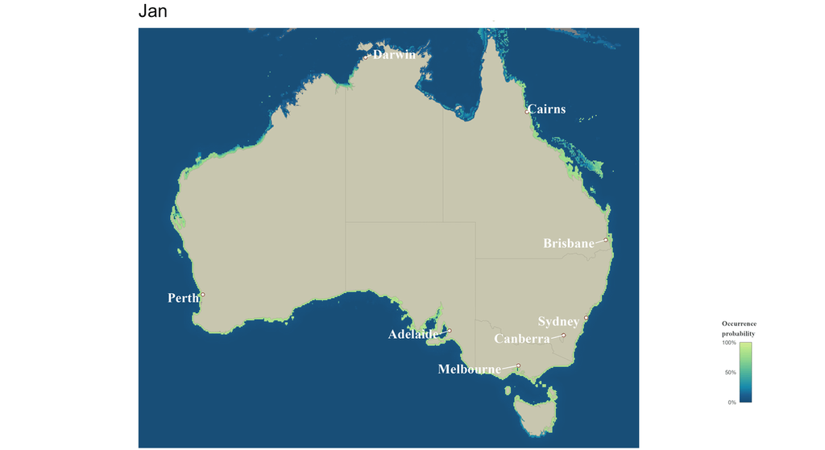

```r
knitr::include_graphics("SDM.gif")
```

We now have our animated GIF! Our animation shows that nudibranchs can be observed all year long, though there are some months where you are more likely to observe nudibranchs in more places than others.

However, when data are broken down into smaller and smaller groups (which often happens over the course of an entire analysis), we increase the chance of *uncertainty* in our results.

[figure not shown]

# Final thoughts

We hope you’ve felt the thrill of constructing your own stop-motion animation with {ggplot2} and {gifski}!

If you are interested in making animations of other types of plots, check out the [{gganimate} package](https://gganimate.com/articles/gganimate.html) or the [{plotly} package](https://plotly.com/ggplot2/animations/), too!

The ALA is made possible by contributions from its partners, is supported by [NCRIS](https://www.education.gov.au/national-collaborative-research-infrastructure-strategy-ncris), is hosted by [CSIRO](https://csiro.au/), and is the Australian node of [GBIF](https://www.gbif.org/en/).

**Acknowledgement of Traditional Owners and Country**

The Atlas of Living Australia acknowledges Australia's Traditional Owners and pays respect to the past and present Elders of the nation's Aboriginal and Torres Strait Islander communities. We honour and celebrate the spiritual, cultural and customary connections of Traditional Owners to country and the biodiversity that forms part of that country.

This work is licensed under a [Creative Commons Attribution 3.0 Australia License](https://creativecommons.org/licenses/by/3.0/au/)

[Copyright](https://www.ala.org.au/terms-of-use#cy) [Terms of Use](https://www.ala.org.au/terms-of-use) [System Status](https://status.ala.org.au/)